# GOV 1006 Pset #5

Maria Burzillo

3/1/2020

# 1: The Effect of Having a Daughter on a Judge’s Liberal Vote Share

## a)

We can use stan_glm to fit a linear model to the data to estimate the effect of having a daughter on a judge’s liberal vote share. The results are displayed in part b.

## b)

**The Effect of Having Daughters on Liberal Vote Share**

| Statistic | N | Mean | St. Dev. | Min | Pctl(25) | Pctl(75) | Max |
| --- | --- | --- | --- | --- | --- | --- | --- |
| Intercept | 4,000 | 0.39 | 0.03 | 0.26 | 0.37 | 0.41 | 0.50 |
| Has Daughters | 4,000 | 0.06 | 0.04 | -0.08 | 0.04 | 0.09 | 0.20 |
| sigma | 4,000 | 0.25 | 0.01 | 0.21 | 0.24 | 0.26 | 0.30 |

## c)

The model fit tells us that the intercept is 0.39 with uncertainty 0.03. This suggests that the expected liberal vote share of someone who does not have a daughter is 0.39.

It also tells us that the coefficient on treatment, or the slope of the model is 0.06 with uncertainty 0.04. This suggests that the expected difference between a judge’s liberal vote share who has daughters and a judge’s liberal vote share who does not have daughters is 0.06.

Furthermore, the residual standard deviation is 0.25. This suggests that the liberal vote share as predicted by the model will be within $\displaystyle \pm \,2\, *$ 0.25 approximately 95% of the time.

# 2: The Estimated Effect of the Number of Daughters

## a) The Estimated Effect of the Number of Daughters on Liberal Vote Share

**The Incremental Effect of Having Daughters on Liberal Vote Share**

| Statistic | N | Mean | St. Dev. | Min | Pctl(25) | Pctl(75) | Max |
| --- | --- | --- | --- | --- | --- | --- | --- |
| Intercept | 4,000 | 0.39 | 0.03 | 0.26 | 0.37 | 0.41 | 0.50 |
| girls1 | 4,000 | 0.06 | 0.04 | -0.11 | 0.03 | 0.09 | 0.21 |
| girls2 | 4,000 | 0.06 | 0.04 | -0.10 | 0.03 | 0.09 | 0.22 |
| girls3 | 4,000 | 0.11 | 0.06 | -0.18 | 0.07 | 0.15 | 0.37 |
| girls4 | 4,000 | -0.16 | 0.14 | -0.64 | -0.26 | -0.07 | 0.32 |
| girls5 | 4,000 | 0.16 | 0.17 | -0.46 | 0.05 | 0.27 | 0.86 |
| sigma | 4,000 | 0.25 | 0.01 | 0.21 | 0.24 | 0.26 | 0.30 |

## b) Controlling for the Effects of Children

In order to control for the potential biases due to having children of any gender on the estimated effect size of having a certain number of daughters on a judge’s vote, we can add additional predictors to the model for the number of children each judge has. This will allow us to better isolate the effects of having a certain number of daughters. The results of the model are presented in the table below.

**The Incremental Effect of Having Daughters on Liberal Vote Share with Controls for Number of Children**

| Statistic | N | Mean | St. Dev. | Min | Pctl(25) | Pctl(75) | Max |
| --- | --- | --- | --- | --- | --- | --- | --- |
| Intercept | 4,000 | 0.45 | 0.05 | 0.28 | 0.42 | 0.49 | 0.65 |
| girls1 | 4,000 | 0.11 | 0.05 | -0.09 | 0.07 | 0.14 | 0.27 |
| girls2 | 4,000 | 0.10 | 0.05 | -0.10 | 0.07 | 0.14 | 0.31 |
| girls3 | 4,000 | 0.15 | 0.08 | -0.12 | 0.10 | 0.20 | 0.42 |
| girls4 | 4,000 | -0.31 | 0.22 | -1.05 | -0.46 | -0.17 | 0.57 |
| girls5 | 4,000 | 0.16 | 0.23 | -0.61 | -0.001 | 0.32 | 0.96 |
| child1 | 4,000 | -0.16 | 0.08 | -0.44 | -0.21 | -0.11 | 0.10 |
| child2 | 4,000 | -0.08 | 0.07 | -0.31 | -0.13 | -0.04 | 0.16 |
| child3 | 4,000 | -0.13 | 0.07 | -0.41 | -0.18 | -0.08 | 0.11 |
| child4 | 4,000 | -0.14 | 0.08 | -0.43 | -0.19 | -0.08 | 0.18 |
| child5 | 4,000 | -0.04 | 0.10 | -0.44 | -0.11 | 0.03 | 0.40 |
| child6 | 4,000 | -0.08 | 0.16 | -0.69 | -0.18 | 0.03 | 0.42 |
| child7 | 4,000 | 0.29 | 0.30 | -0.75 | 0.09 | 0.49 | 1.25 |
| child8 | 4,000 | 0.02 | 0.30 | -1.11 | -0.18 | 0.23 | 1.16 |
| child9 | 4,000 | -0.10 | 0.31 | -1.21 | -0.30 | 0.10 | 1.10 |
| sigma | 4,000 | 0.25 | 0.01 | 0.21 | 0.24 | 0.26 | 0.31 |

The results of the model are quite complicated and difficult to understand. The intercept suggests that we would expect a judge with no daughters or children to have an average liberal vote share of 0.45. The coefficients of “girlsx” suggest that we expect a judge with x number of girls to have an increase/decrease in liberal vote share according to the mean of their respective row compared to a judge with no daughters (the default here for the variable girls) and the same number of children. So for example, the coefficient of “girls3” suggests that a judge with 3 daughters would be expected to have a liberal vote share 0.15 points higher than a judge with no daughters and the same number of children.

As with the previous model without controlling for the number of children, these results suggest that judges become more liberal when they have daughters. The coefficients of “girls4” and “girls5” seem to deviate from the general trend; however, there are only 3 observations with judges having 4 girls and 2 observations with judges having 5 girls, so the extremely small sample size in those factor levels may be skewing the results. The coefficients for having 1 girl, 2 girls, and 3 girls are slightly larger in this model than they were in the model not controlling for children. This further suggests that there is something specific about having daughters that can correlate with a more liberal vote share.

The effect of having children in general tends to be negative. Again, the coefficients on “child7”, “child8”, and “child9”, also seem to deviate from the trend, but there is only 1 judge in each of these categories, which is highly problematic. It would probably be better to exclude these data or to bin by the number of children in some way to avoid this. Another important note is that the 50% confidence intervals on the coefficients for having 5 children and 6 children contain 0, which sheds some uncertainty about the sign of the actual effect. These uncertainties should motivate further investigation or at least the checking of 95% confidence intervals.

## c) Controlling for Partisanship

In order to investigate how a judge’s partisanship mediates the effect of having daughters on the judge’s vote, we can fit a model using an indicator for whether or not the judge has daughters and an indicator for whether or not the judge is a republican to explain liberal vote share. It makes sense to use the indicator variable for whether or not a judge has daughters as oppossed to the incremental factor for the number of daughters since we are more interested in looking at the effect of having any daughters on liberal vote share rather than the effect of a specific number of daughters as mediated by the partisan status in either case. After fitting the model, we can create a scatter plot of jittered points, each representing a judge, showing liberal vote share versus the indicator for having daughters.

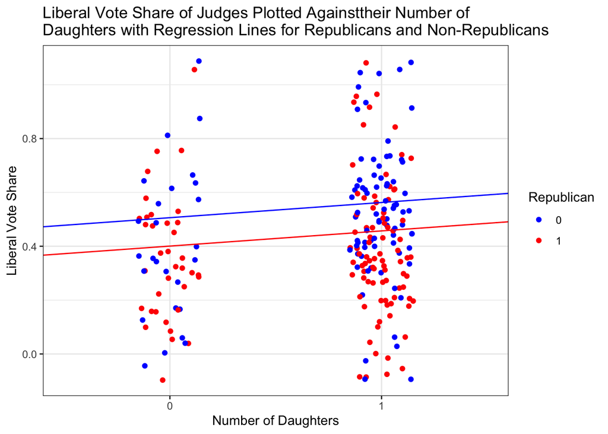

# 3: Control Variables and Interaction Effects

**The Effect of Having Daughters, Being a Woman**

| Statistic | N | Mean | St. Dev. | Min | Pctl(25) | Pctl(75) | Max |
| --- | --- | --- | --- | --- | --- | --- | --- |
| Intercept | 4,000 | 0.393 | 0.038 | 0.222 | 0.367 | 0.419 | 0.527 |
| Has Daughters | 4,000 | 0.057 | 0.043 | -0.104 | 0.027 | 0.087 | 0.215 |
| Is Woman | 4,000 | -0.018 | 0.069 | -0.254 | -0.066 | 0.029 | 0.242 |
| Has Daughters x Is Woman | 4,000 | 0.014 | 0.091 | -0.331 | -0.049 | 0.078 | 0.314 |
| sigma | 4,000 | 0.250 | 0.012 | 0.199 | 0.241 | 0.257 | 0.299 |

The intercept of this model suggests that a non-woman with no daughters is expected to have a liberal vote share of 0.393 on average. The coefficient on having daughters suggests that the expected difference between a non-woman judge who has daughters and a non-woman judge who does not is 0.057. Similarly, the coefficient on being a woman suggests that the expected difference between a female judge with no daughters and a non-woman judge with no daughters is -0.019. Finally, the coefficient on the interaction of having daughters and being a woman is 0.014, which suggests that having a daughter and being a woman leads to an expected difference of 0.014 points in liberal vote share compared to a judge not being a woman and not having daughters. The residual standard deviaton term, sigma, in the model suggests that actual liberal vote share will be within ${\displaystyle \pm }$ 0.249 points of the linear predictor 68% of the time.

**Model Fit with Fake Data Simulation**

| Statistic | N | Mean | St. Dev. | Min | Pctl(25) | Pctl(75) | Max |
| --- | --- | --- | --- | --- | --- | --- | --- |
| Intercept | 4,000 | 0.586 | 0.187 | -0.196 | 0.459 | 0.707 | 1.237 |
| Has Daughters | 4,000 | -0.038 | 0.110 | -0.386 | -0.111 | 0.037 | 0.369 |
| Is Woman | 4,000 | -0.115 | 0.139 | -0.594 | -0.207 | -0.021 | 0.393 |
| Has Daughters x Is Woman | 4,000 | 0.047 | 0.085 | -0.224 | -0.012 | 0.102 | 0.317 |
| sigma | 4,000 | 0.239 | 0.011 | 0.200 | 0.232 | 0.246 | 0.289 |

# 4. Simulated Confidence Intervals

Using the simulated data from the model generated in question 1, we can construct 95% confidence intervals for the intercept and treatment coeficients. We find that the confidence interval for the intercept is (0.33, 0.45) and the confidence interval for the treatment is (-0.01, 0.13).

These confidence intervals represent the range within which the true value of the desired parameter is expected to be contained 95% of the time on average. For example, this means that the interval (0.33, 0.45) has a 95% chance of containing the true intercept. Similarly, the interval (-0.01, 0.13) has an approximately 95% chance of containing the true treatment coefficient.

We can compare the calculated confidence intervals to the approximation of the confidence intervals using the median and mad sd from the original model fitting. In our original fitted model, the intercept coefficient had value 0.39 with mad sd 0.03. This would yield an estimated 95% confidence interval of 0.39 $\displaystyle \pm \,2\, *$ 0.03, or (0.33,0.45). Similarly, in our original fitted model, the treatment coefficient had the value 0.06 with mad sd 0.04. This would yield an estimated 95% confidence interval of 0.06 $\displaystyle \pm \,2\, *$ 0.04, or (-0.01,0.13). These approximations are very similar to our confidence intervals calculated from the simulations. Interestingly, both the confidence intervals estimated for the treatment coefficient contain zero, which suggests that the sign of the effect is unclear.